# Time series analysis Mohamed Boudjemai

Analyse de l’ensemble de données de partage de vélos

Les systèmes de partage de vélos sont une nouvelle génération de location de vélos traditionnels où tout le processus d’adhésion, de location et de retour est devenu automatique. Grâce à ces systèmes, l’utilisateur peut facilement louer un vélo à partir d’une position particulière et revenir à une autre position. Actuellement, il existe environ 500 programmes de vélos en libre-service dans le monde, composés de plus de 500 milliers de vélos. Aujourd’hui, ces systèmes suscitent un grand intérêt en raison de leur rôle important dans les problèmes de circulation, d’environnement et de santé.

Outre les applications intéressantes des systèmes de vélos en libre-service dans le monde réel, les caractéristiques des données générées par ces systèmes les rendent attractifs pour la recherche. Contrairement à d’autres services de transport comme le bus ou le métro, la durée du trajet, la position de départ et d’arrivée est explicitement enregistrée dans ces systèmes. Cette fonction transforme le système de partage de vélos en un réseau de capteurs virtuels qui peut être utilisé pour détecter la mobilité en ville. Par conséquent, on s’attend à ce que la plupart des événements importants dans la ville puissent être détectés grâce à la surveillance de ces données.

Cet ensemble de données contient le décompte horaire et quotidien des vélos de location entre les années 2011 et 2012 dans le système de partage de vélos Capital à Washington, DC avec les informations météorologiques et saisonnières correspondantes.

Content Both hour.csv and day.csv have the following fields, except hr which is not available in day.csv • instant: Record index • dteday: Date • season: Season (1:springer, 2:summer, 3:fall, 4:winter) • yr: Year (0: 2011, 1:2012) • mnth: Month (1 to 12) • hr: Hour (0 to 23) • holiday: weather day is holiday or not (extracted from Holiday Schedule) • weekday: Day of the week • workingday: If day is neither weekend nor holiday is 1, otherwise is 0. • weathersit: (extracted from Freemeteo) • 1: Clear, Few clouds, Partly cloudy, Partly cloudy • 2: Mist + Cloudy, Mist + Broken clouds, Mist + Few clouds, Mist • 3: Light Snow, Light Rain + Thunderstorm + Scattered clouds, Light Rain + Scattered clouds • 4: Heavy Rain + Ice Pallets + Thunderstorm + Mist, Snow + Fog • temp: Normalized temperature in Celsius. The values are derived via (t-t_min)/(t_max-t_min), t_min=-8, t_max=+39 (only in hourly scale) • atemp: Normalized feeling temperature in Celsius. The values are derived via (t-t_min)/(t_max-t_min), t_min=-16, t_max=+50 (only in hourly scale) • hum: Normalized humidity. The values are divided to 100 (max) • windspeed: Normalized wind speed. The values are divided to 67 (max) • casual: count of casual users • registered: count of registered users • cnt: count of total rental bikes including both casual and registered

1. Examine your data Data : https://archive.ics.uci.edu/ml/datasets/Bike+Sharing+Dataset

```r
day.data <- read.csv(file = "C:/INFO DESCARTES/M2/TEMPOTRELLE/day.csv")
Hours <- read.csv(file = "C:/INFO DESCARTES/M2/TEMPOTRELLE/hour.csv")
print("_______________________importation des données_________________")
```

```
[1] "_______________________importation des données_________________"
```

```r
print("______________Dimension__________")
```

```
[1] "______________Dimension__________"
```

```r
print(dim(day.data))
```

```
[1] 731  16
```

```r
print(dim(hour.data))
```

```
[1] 17379    17
```

```r
print("______________nom des attributs___________________")
```

```
[1] "______________nom des attributs___________________"
```

```r
print(names(day.data))
```

```
 [1] "instant"    "dteday"     "season"     "yr"         "mnth"
 [6] "holiday"    "weekday"    "workingday" "weathersit" "temp"
[11] "atemp"      "hum"        "windspeed"  "casual"     "registered"
[16] "cnt"
```

```r
print("____________________________________________________________")
```

```
[1] "____________________________________________________________"
```

```r
print(names(hour.data))
```

```
 [1] "instant"    "dteday"     "season"     "yr"         "mnth"
 [6] "hr"         "holiday"    "weekday"    "workingday" "weathersit"
[11] "temp"       "atemp"      "hum"        "windspeed"  "casual"
[16] "registered" "cnt"
```

```r
summary(day.data)
```

```
    instant         dteday              season            yr
 Min.   :  1.0   Length:731         Min.   :1.000   Min.   :0.0000
 1st Qu.:183.5   Class :character   1st Qu.:2.000   1st Qu.:0.0000
 Median :366.0   Mode  :character   Median :3.000   Median :1.0000
 Mean   :366.0                      Mean   :2.497   Mean   :0.5007
 3rd Qu.:548.5                      3rd Qu.:3.000   3rd Qu.:1.0000
 Max.   :731.0                      Max.   :4.000   Max.   :1.0000
      mnth          holiday           weekday        workingday
 Min.   : 1.00   Min.   :0.00000   Min.   :0.000   Min.   :0.000
 1st Qu.: 4.00   1st Qu.:0.00000   1st Qu.:1.000   1st Qu.:0.000
 Median : 7.00   Median :0.00000   Median :3.000   Median :1.000
 Mean   : 6.52   Mean   :0.02873   Mean   :2.997   Mean   :0.684
 3rd Qu.:10.00   3rd Qu.:0.00000   3rd Qu.:5.000   3rd Qu.:1.000
 Max.   :12.00   Max.   :1.00000   Max.   :6.000   Max.   :1.000
   weathersit         temp             atemp              hum
 Min.   :1.000   Min.   :0.05913   Min.   :0.07907   Min.   :0.0000
 1st Qu.:1.000   1st Qu.:0.33708   1st Qu.:0.33784   1st Qu.:0.5200
 Median :1.000   Median :0.49833   Median :0.48673   Median :0.6267
 Mean   :1.395   Mean   :0.49538   Mean   :0.47435   Mean   :0.6279
 3rd Qu.:2.000   3rd Qu.:0.65542   3rd Qu.:0.60860   3rd Qu.:0.7302
 Max.   :3.000   Max.   :0.86167   Max.   :0.84090   Max.   :0.9725
   windspeed           casual         registered        cnt
 Min.   :0.02239   Min.   :   2.0   Min.   :  20   Min.   :  22
 1st Qu.:0.13495   1st Qu.: 315.5   1st Qu.:2497   1st Qu.:3152
 Median :0.18097   Median : 713.0   Median :3662   Median :4548
 Mean   :0.19049   Mean   : 848.2   Mean   :3656   Mean   :4504
 3rd Qu.:0.23321   3rd Qu.:1096.0   3rd Qu.:4776   3rd Qu.:5956
 Max.   :0.50746   Max.   :3410.0   Max.   :6946   Max.   :8714
```

```r
summary(hour.data)
```

```
    instant         dteday              season            yr
 Min.   :    1   Length:17379       Min.   :1.000   Min.   :0.0000
 1st Qu.: 4346   Class :character   1st Qu.:2.000   1st Qu.:0.0000
 Median : 8690   Mode  :character   Median :3.000   Median :1.0000
 Mean   : 8690                      Mean   :2.502   Mean   :0.5026
 3rd Qu.:13034                      3rd Qu.:3.000   3rd Qu.:1.0000
 Max.   :17379                      Max.   :4.000   Max.   :1.0000
      mnth              hr           holiday           weekday
 Min.   : 1.000   Min.   : 0.00   Min.   :0.00000   Min.   :0.000
 1st Qu.: 4.000   1st Qu.: 6.00   1st Qu.:0.00000   1st Qu.:1.000
 Median : 7.000   Median :12.00   Median :0.00000   Median :3.000
 Mean   : 6.538   Mean   :11.55   Mean   :0.02877   Mean   :3.004
 3rd Qu.:10.000   3rd Qu.:18.00   3rd Qu.:0.00000   3rd Qu.:5.000
 Max.   :12.000   Max.   :23.00   Max.   :1.00000   Max.   :6.000
   workingday       weathersit         temp           atemp
 Min.   :0.0000   Min.   :1.000   Min.   :0.020   Min.   :0.0000
 1st Qu.:0.0000   1st Qu.:1.000   1st Qu.:0.340   1st Qu.:0.3333
 Median :1.0000   Median :1.000   Median :0.500   Median :0.4848
 Mean   :0.6827   Mean   :1.425   Mean   :0.497   Mean   :0.4758
 3rd Qu.:1.0000   3rd Qu.:2.000   3rd Qu.:0.660   3rd Qu.:0.6212
 Max.   :1.0000   Max.   :4.000   Max.   :1.000   Max.   :1.0000
      hum           windspeed          casual         registered
 Min.   :0.0000   Min.   :0.0000   Min.   :  0.00   Min.   :  0.0
 1st Qu.:0.4800   1st Qu.:0.1045   1st Qu.:  4.00   1st Qu.: 34.0
 Median :0.6300   Median :0.1940   Median : 17.00   Median :115.0
 Mean   :0.6272   Mean   :0.1901   Mean   : 35.68   Mean   :153.8
 3rd Qu.:0.7800   3rd Qu.:0.2537   3rd Qu.: 48.00   3rd Qu.:220.0
 Max.   :1.0000   Max.   :0.8507   Max.   :367.00   Max.   :886.0
      cnt
 Min.   :  1.0
 1st Qu.: 40.0
 Median :142.0
 Mean   :189.5
 3rd Qu.:281.0
 Max.   :977.0
```

[figure not shown]

```r
plot(day.data)
```

```r
print("_______________structure________________")
```

```
[1] "_______________structure________________"
```

```r
str(day.data)
```

```
'data.frame':   731 obs. of  16 variables:
 $ instant   : int  1 2 3 4 5 6 7 8 9 10 ...
 $ dteday    : chr  "2011-01-01" "2011-01-02" "2011-01-03" "2011-01-04" ...
 $ season    : int  1 1 1 1 1 1 1 1 1 1 ...
 $ yr        : int  0 0 0 0 0 0 0 0 0 0 ...
 $ mnth      : int  1 1 1 1 1 1 1 1 1 1 ...
 $ holiday   : int  0 0 0 0 0 0 0 0 0 0 ...
 $ weekday   : int  6 0 1 2 3 4 5 6 0 1 ...
 $ workingday: int  0 0 1 1 1 1 1 0 0 1 ...
 $ weathersit: int  2 2 1 1 1 1 2 2 1 1 ...
 $ temp      : num  0.344 0.363 0.196 0.2 0.227 ...
 $ atemp     : num  0.364 0.354 0.189 0.212 0.229 ...
 $ hum       : num  0.806 0.696 0.437 0.59 0.437 ...
 $ windspeed : num  0.16 0.249 0.248 0.16 0.187 ...
 $ casual    : int  331 131 120 108 82 88 148 68 54 41 ...
 $ registered: int  654 670 1229 1454 1518 1518 1362 891 768 1280 ...
 $ cnt       : int  985 801 1349 1562 1600 1606 1510 959 822 1321 ...
```

```r
is.null(day.data)
```

```
[1] FALSE
```

```r
print(" pas de valeur null")
```

```
[1] " pas de valeur null"
```

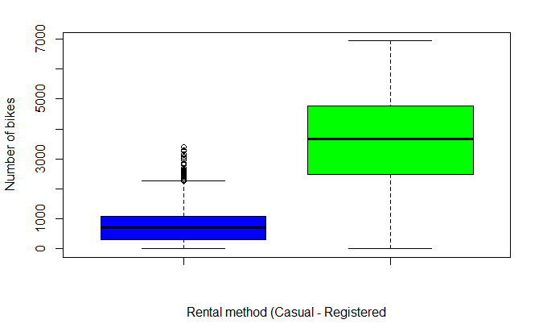

```r
boxplot(day.data$casual ,day.data$registered, col = c("blue", "green"), ylab = "Number of bikes", xlab = "Rental method (Casual - Registered")
```

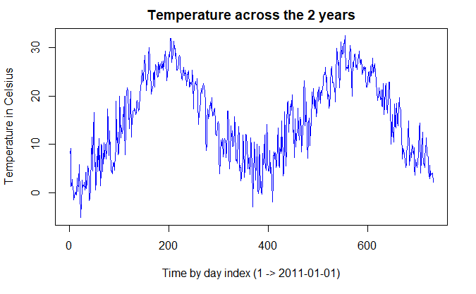

```r
day.data$temp.cel <- day.data$temp*(39 + 8) - 8
day.temp <- ts(day.data$temp.cel)
plot(day.temp, main = "Temperature across the 2 years", ylab="Temperature in Celsius", col="blue", xlab="Time by day index (1 -> 2011-01-01)")
```

La température augmente au début de chaque année (printemps et été), atteignant son maximum en été, puis continue de baisser (automne et hiver) jusqu’à la fin de l’année.

Q2 - Quelles sont les températures moyennes et médianes? Température moyenne et médiane du printemps

```r
spring.temp <- subset(day.data, season == 1)$temp.cel
print(mean(spring.temp))
```

```
[1] 5.994135
```

```r
print(median(spring.temp))
```

```
[1] 5.434151
```

Température moyenne et médiane de l’été

```r
summer.temp <- subset(day.data, season == 2)$temp.cel
print(mean(summer.temp))
```

```
[1] 17.58704
```

```r
print(median(summer.temp))
```

```
[1] 18.41792
```

Température moyenne et médiane de l’automne

```r
fall.temp <- subset(day.data, season == 3)$temp.cel
print(mean(fall.temp))
```

```
[1] 25.19654
```

```r
print(median(fall.temp))
```

```
[1] 25.5854
```

Température moyenne et médiane de l’hiver

```r
winter.temp <- subset(day.data, season == 4)$temp.cel
print(mean(winter.temp))
```

```
[1] 11.87658
```

```r
print(median(winter.temp))
```

```
[1] 11.23083
```

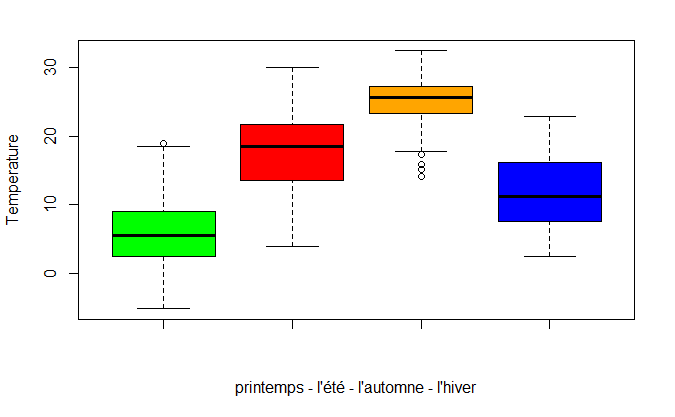

```r
boxplot(subset(day.data, season == 1)$temp.cel, subset(day.data, season == 2)$temp.cel, subset(day.data, season == 3)$temp.cel, subset(day.data, season == 4)$temp.cel, col = c("green", "red", "orange", "blue"), xlab = "printemps - l'été - l'automne - l'hiver", ylab = "Temperature")
```

```r
day = day.data
# Converting the nomalized temperature:
day$raw.temp <- (day$temp*41)
#2. Calculating Median, Mean and Standard deviation of spring.
spring <- subset(day, season == 1)$raw.temp
sp.mean <- mean(spring)
sp.median <- median(spring)
sp.sd <- sd(spring)


#3. Calculating Median, Mean and Standard deviation of summer.
summer <- subset(day, season == 2)$raw.temp
su.mean <- mean(summer)
su.median <- median(summer)
su.sd <- sd(summer)


#3. Calculating Median, Mean and Standard deviation of fall.
fall <- subset(day, season == 3)$raw.temp
fa.mean <- mean(fall)
fa.median <-median(fall)
fa.sd <- sd(fall)


#4. Calculating Median, Mean and Standard deviation of winter.
winter <- subset(day, season == 4)$raw.temp
wi.mean <- mean(winter)
wi.median <- median(winter)
wi.sd <- sd(winter)
```

Printemps: La température moyenne du printemps était de 12,21. La température médiane du printemps était de 11,72. L’écart type de la température au printemps était de 4,21. Été: La température moyenne de l’été était de 22,32. La température médiane de l’été était de 23,05. L’écart type de la température en été était de 5,03. Tombe: La température moyenne de chute était de 28,96. La température médiane de chute était de 29,3. L’écart type de la température à l’automne était de 2,9. Hiver: La température moyenne de l’hiver était de 17,34. La température médiane de l’hiver était de 16,78. L’écart type de la température en hiver était de 4,42.

```r
#create histogram for the distribution of temperatures in spring.
hist(x = spring,
     main = "Temperatures in Spring",
     xlab = "Temperature in Celcius",
     ylab = "Number of Days",
     xlim = c(0, 25),
     ylim = c(0, 45))

abline(v = sp.mean, lwd = 2, lty = 1, col = "red")
```

```r
text(x = 17, y = 35,
     labels = paste("Mean = ", round(mean(spring),2), sep = ""), col="red" )

abline(v = sp.median, lwd = 2, lty = 3, col = "blue")
```

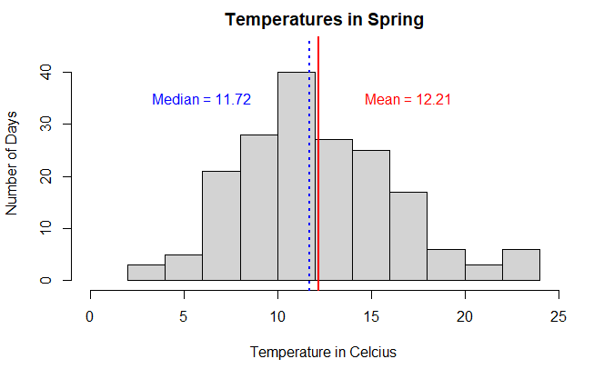

```r
text(x = 6, y = 35,
     labels = paste("Median = ", round(median(spring),2), sep = ""), col="blue" )
```

```r
#create a histogram for the distribution of temperatures in summer.
hist(x = summer,
     main = "Temperatures in Summer",
     xlab = "Temperature in Celcius",
     ylab = "Number of Days",
      xlim = c(0, 35), ylim = c(0, 40)
    )
abline(v = su.mean, lwd = 2, lty = 1, col = "red")
```

```r
text( x = 15, y = 40,
     labels = paste("Mean = ", round(mean(summer),2), sep = ""),
col = "red")

abline(v = su.median, lwd = 2, lty = 3, col = "blue")
```

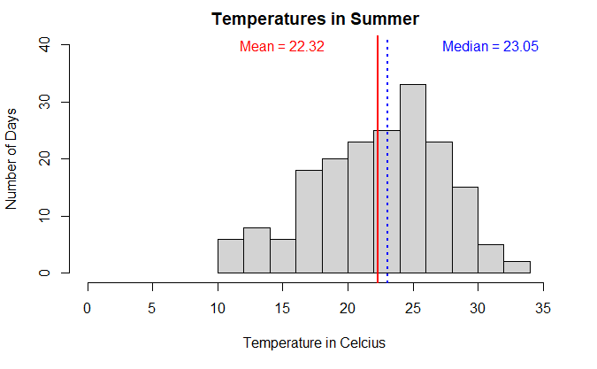

```r
text(x = 31, y = 40,
     labels = paste("Median = ", round(median(summer),2), sep = ""), col = "blue" )
```

```r
#create a histogram for the distribution of temperatures in fall.
hist(x = fall,
     main = "Temperatures in Fall",
     xlab = "Temperature in Celcius",
     ylab = "Number of Days",
      xlim = c(15, 40), ylim = c(0, 70)
    )
abline(v = fa.mean, lwd = 2, lty = 1, col = "red")
```

```r
text(x = 24, y = 60,
     labels = paste("Mean = ", round(mean(fall),3), sep = ""), col = "red" )

abline(v = fa.median, lwd = 2, lty = 3, col ="blue")
```

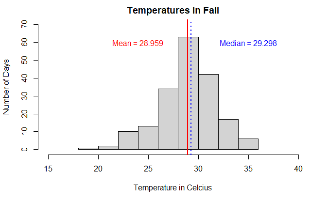

```r
text(x = 35, y = 60,
     labels = paste("Median = ", round(median(fall),3), sep = ""), col ="blue" )
```

```r
#create a histogram for the distribution of temperatures in winter.
hist(x = winter,
     main = "Temperatures in Winter",
     xlab = "Temperature in Celcius",
     ylab = "Number of Days",
    xlim = c(0, 30), ylim = c(0, 40)
    )

abline(v = wi.mean, lwd = 2, lty = 1, col = "red")
```

```r
text(x = 23, y = 40,
     labels = paste("Mean = ", round(mean(winter),2), sep = ""), col = "red" )

abline(v = wi.median, lwd = 2, lty = 3, col ="blue")
```

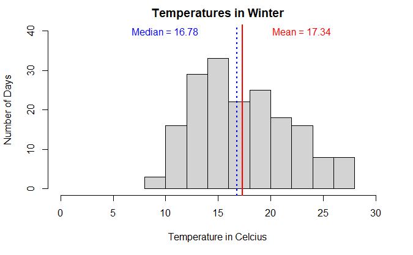

```r
text(x = 10, y = 40,
     labels = paste("Median = ", round(median(winter),2), sep = ""), col ="blue" )
```

```r
#The Dataset is already recoded and correct.
#For this question we converted "atemp" because it was devided of 50.
day$raw.atemp <-(day$atemp * 50)

#Create a new column of the mean of raw.temp and raw.atemp.
day$raw.mean.temp.atemp <- (day$raw.temp + day$raw.atemp)/2
#Correlation between raw.temp and the total count of bike rentals.

cor.temp <- cor.test(x = day$raw.temp,
y = day$cnt)

cor.temp
```

```
    Pearson's product-moment correlation

data:  day$raw.temp and day$cnt
t = 21.759, df = 729, p-value < 2.2e-16
alternative hypothesis: true correlation is not equal to 0
95 percent confidence interval:
 0.5814369 0.6695422
sample estimates:
     cor
0.627494
```

```r
Temperature <- day$raw.temp
Amount.Rentals <- day$cnt
#Correlation between atemp and the total count of bike rentals.
cor.atemp <- cor.test(x = day$raw.atemp,
y = day$cnt)
cor.atemp
```

```
    Pearson's product-moment correlation

data:  day$raw.atemp and day$cnt
t = 21.965, df = 729, p-value < 2.2e-16
alternative hypothesis: true correlation is not equal to 0
95 percent confidence interval:
 0.5853376 0.6727918
sample estimates:
      cor
0.6310657
```

```r
Feeled.Temperature <- day$raw.atemp
Amount.Rentals <- day$cnt
#Correlation between mean.temp.atemp and the total count of bike rentals.
day$raw.mean.temp.atemp <-(day$raw.temp + day$raw.atemp)/2
cor.mean.temp.atemp <- cor.test(x = day$raw.mean.temp.atemp,
y = day$cnt)
cor.mean.temp.atemp
```

```
    Pearson's product-moment correlation

data:  day$raw.mean.temp.atemp and day$cnt
t = 21.941, df = 729, p-value < 2.2e-16
alternative hypothesis: true correlation is not equal to 0
95 percent confidence interval:
 0.5848953 0.6724234
sample estimates:
      cor
0.6306607
```

```r
Feeled.Raw.Temperature <- day$raw.mean.temp.atemp
Amount.Rentals <- day$cnt
```

```r
par(mfrow=c(2,2))

plot(x = Temperature, y = Amount.Rentals, main = "Correlation", col = "red")
abline(lm(Amount.Rentals ~ Temperature), col = "blue")
```

```r
legend("topleft", legend = paste("cor = ", round(cor(Temperature, Amount.Rentals), 2), sep = ""),lty = 1, col = "blue")

plot(x = Feeled.Temperature, y = Amount.Rentals, main = "Correlation", col = "blue")
```

```r
abline(lm(Amount.Rentals ~ Feeled.Temperature), col = "red")
legend("topleft", legend = paste("cor = ", round(cor(Feeled.Temperature, Amount.Rentals), 2), sep = ""),lty = 1, col = "red")
```

```r
plot(x = Feeled.Raw.Temperature, y = Amount.Rentals, main = "Correlation", col = "green")
abline(lm(Amount.Rentals ~ Feeled.Raw.Temperature), col = "orange")
```

```r
legend("topleft", legend = paste("cor = ", round(cor(Temperature, Amount.Rentals), 2), sep = ""),lty = 1, col = "orange")


plot(x = 1, y = 1, xlab = "Temperature", ylab = "Amount of rentals", xlim = c(0, 40), ylim = c(0, 10000), main = "Three correlations combined")
```

```r
points(Feeled.Raw.Temperature, Amount.Rentals, pch = 8, col = "green")
points(Temperature, Amount.Rentals, pch = 8, col = "red")
```

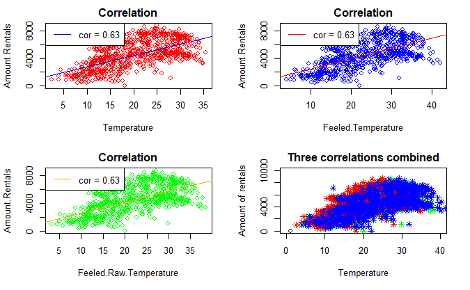

```r
points(Feeled.Temperature, Amount.Rentals, pch = 8, col = "blue")
```

```r
# Changing the names of columns
names(Day)[4:5]<-c("year","month")
names(Day)[2]<-c("date")
names(Day)[12]<-c("humidity")
names(Day)[16]<-c("count")
# Checking for null values
is.null(Day)
```

```
[1] FALSE
```

```r
Day$year<-factor(Day$year,levels = c(0,1),labels =c(2011,2012))
table(Day$year)
```

```
2011 2012
 365  366
```

```r
Day$season<-factor(Day$season,levels = c(1,2,3,4),labels = c('spring','summer','fall','winter'))
table(Day$season)
```

```
spring summer   fall winter
   181    184    188    178
```

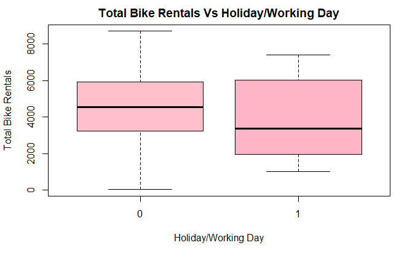

```r
# Boxplot for Count vs Holiday

boxplot(Day$count ~ Day$holiday,
        data =Day,
        main = "Total Bike Rentals Vs Holiday/Working Day",
        xlab = "Holiday/Working Day",
        ylab = "Total Bike Rentals",
        col = c("pink", "pink1", "pink2", "pink3"))
```

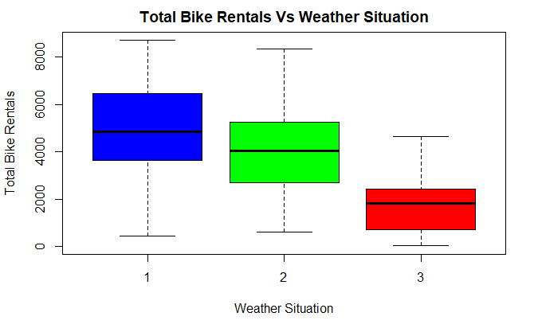

```r
#Boxplot for count vs weathersituation
boxplot(Day$count ~ Day$weathersit,
        data = Day,
        main = "Total Bike Rentals Vs Weather Situation",
        xlab = "Weather Situation",
        ylab = "Total Bike Rentals",
        col = c("blue", "green", "red", "yellow"))
```

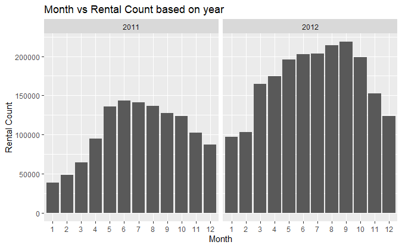

```r
library(ggplot2)
#"Month vs Rental Count based on year
ggplot(data=Day)+geom_col(aes(x=factor(month),y=count))+
  expand_limits(y=0)+facet_wrap(~year)+xlab("Month")+ylab("Rental Count")+ggtitle("Month vs Rental Count based on year")
```

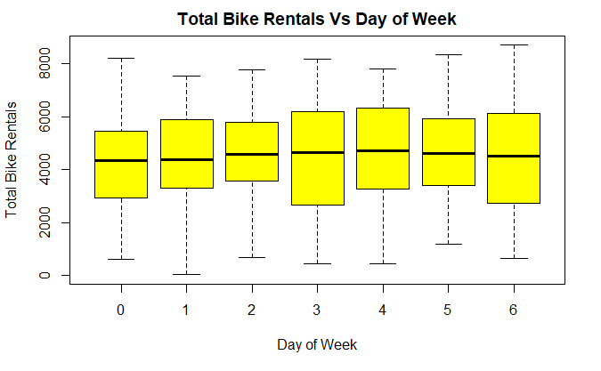

```r
# Rental vs weekday

boxplot(Day$count ~ Day$weekday,
        data = Day,
        main = "Total Bike Rentals Vs Day of Week",
        xlab = "Day of Week",
        ylab = "Total Bike Rentals",
        col = c("yellow"))
```

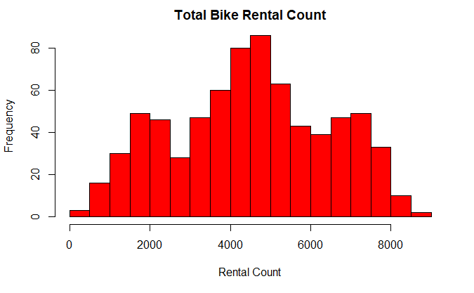

```r
# Histograms

# Total rental count
hist(Day$count, breaks = 20,
     ylab = 'Frequency', xlab = 'Rental Count',
     main = 'Total Bike Rental Count', col = 'Red' )
```

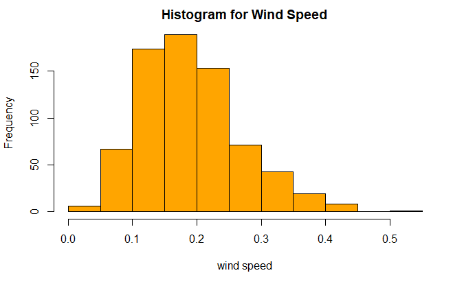

```r
# Windspeed
hist(Day$windspeed, main="Histogram for Wind Speed",
     xlab="wind speed", col = "orange")
```

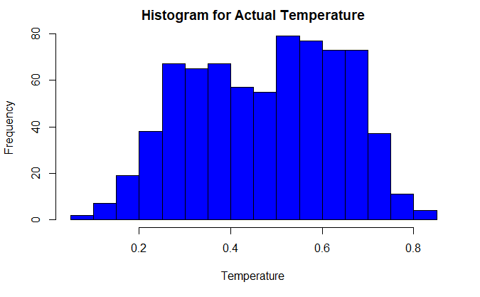

```r
# Actual temperature
hist(Day$atemp, main="Histogram for Actual Temperature",
     xlab="Temperature", col = "blue")
```

```r
Day= day.data
# Humidity
hist(Day$humidity, main="Histogram for Humidity",
     xlab="Humidity", col = "maroon")
```

[output not shown]

Le graphique montre la relation entre la variable Total Bike Rentals (cnt) et les vacances. On constate que le nombre moyen de locations de vélos les jours ouvrables est plus élevé que les vacances.

Le graphique montre la relation entre la variable Total Bike Rentals (cnt) et la météo. Il y a une tendance nettement à la baisse des locations de vélos lorsque le temps est mauvais.

Le graphique montre la relation entre la variable Total Bike Rentals (cnt) et l’année. Nous pouvons voir que la tendance générale a augmenté au cours de la période de deux ans. Et chaque année, il y a énormément de locations de vélos pendant les saisons d’été et d’automne.

```r
bk_sh_dy <- day.data
par(mfrow=c(2,2))
bk_sh_dy$season <- factor(format(bk_sh_dy$season, format="%A"),
                          levels = c("1", "2","3","4") , labels = c("Spring","Summer","Fall","Winter"))
table(bk_sh_dy$season)
```

```
Spring Summer   Fall Winter
   181    184    188    178
```

```r
bk_sh_dy$holiday <- factor(format(bk_sh_dy$holiday, format="%A"),
                          levels = c("0", "1") , labels = c("Working Day","Holiday"))
table(bk_sh_dy$holiday)
```

```
Working Day     Holiday
        710          21
```

```r
bk_sh_dy$weathersit <- factor(format(bk_sh_dy$weathersit, format="%A"),
                          levels = c("1", "2","3","4") ,
               labels = c("Good:Clear/Sunny","Moderate:Cloudy/Mist","Bad: Rain/Snow/Fog","Worse: Heavy Rain/Snow/Fog"))
table(bk_sh_dy$weathersit)
```

```
          Good:Clear/Sunny       Moderate:Cloudy/Mist         Bad: Rain/Snow/Fog
                       463                        247                         21
Worse: Heavy Rain/Snow/Fog
                         0
```

```r
bk_sh_dy$yr <- factor(format(bk_sh_dy$yr, format="%A"),
                          levels = c("0", "1") , labels = c("2011","2012"))
table(bk_sh_dy$yr)
```

```
2011 2012
 365  366
```

```r
bk_sh_dy$actual_temp <- bk_sh_dy$temp*41
bk_sh_dy$actual_feel_temp <- bk_sh_dy$atemp*50
bk_sh_dy$actual_windspeed <- bk_sh_dy$windspeed*67
bk_sh_dy$actual_humidity <- bk_sh_dy$hum*100
bk_sh_dy$mean_acttemp_feeltemp <- (bk_sh_dy$actual_temp+bk_sh_dy$actual_feel_temp)/2
```

```r
par(mfrow=c(2,2))

plot(bk_sh_dy$actual_temp, bk_sh_dy$cnt ,type = 'h', col= 'yellow', xlab = 'Actual Temperature', ylab = 'Total Bike Rentals')

plot(bk_sh_dy$actual_feel_temp, bk_sh_dy$cnt ,type = 'h', col= 'yellow', xlab = 'Actual Feel Temperature', ylab = 'Total Bike Rentals')
```

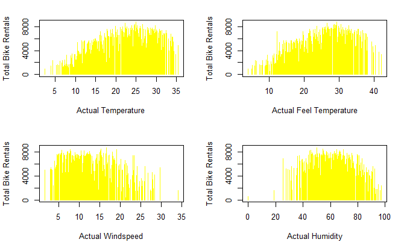

```r
plot(bk_sh_dy$actual_windspeed, bk_sh_dy$cnt ,type = 'h', col= 'yellow', xlab = 'Actual Windspeed', ylab = 'Total Bike Rentals')

plot(bk_sh_dy$actual_humidity, bk_sh_dy$cnt ,type = 'h', col= 'yellow', xlab = 'Actual Humidity', ylab = 'Total Bike Rentals')
```

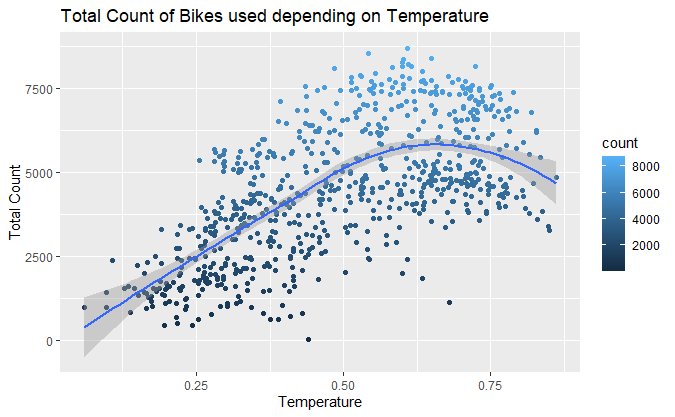

```r
# Count on Temperature
ggplot (Day, aes( x= temp, y = count, colour = count))+geom_point()+geom_smooth()+xlab("Temperature") + ylab ("Total Count")+ggtitle("Total Count of Bikes used depending on Temperature")
```

Q3 - Y a-t-il une corrélation entre le temp / atemp / mean.temp.atemp et le nombre total de locations de vélos? Nous ajoutons d’abord deux nouvelles colonnes à l’ensemble de données.

```r
day.data$atemp.cel <- day.data$atemp*(50 + 16) - 16
day.data$mean.temp.atemp = (day.data$temp.cel + day.data$atemp.cel)/2
```

Ensuite, nous calculons les corrélations: * Corrélation entre le temp et le cnt

```r
cor(day.data$temp.cel, day.data$cnt, method = c("pearson"))
```

```
[1] 0.627494
```

Corrélation entre l’atemp et le cnt

```r
cor(day.data$atemp.cel, day.data$cnt, method = c("pearson"))
```

```
[1] 0.6310657
```

Corrélation entre mean.temp.atemp et cnt

```r
cor(day.data$mean.temp.atemp, day.data$cnt, method = c("pearson"))
```

```
[1] 0.6307721
```

Les valeurs de corrélation sont supérieures à 0,6. Nous pouvons affirmer qu’il existe une corrélation entre les 3 variables de température et le nombre total de locations de vélos.

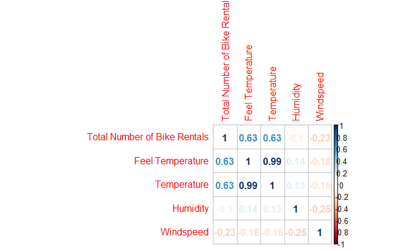

```r
library(corrplot)
corplot_Day <- cor(Day_cor)
corrplot(corplot_Day, method="number")
```

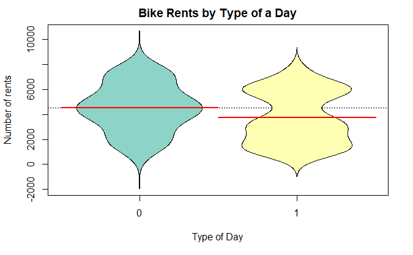

```r
# bean plot for holiday vs working day
t <- t.test(Day$count[Day$holiday == 0],Day$count[Day$holiday == 1])

library(beanplot)
library(RColorBrewer)
bean.cols <- lapply(brewer.pal(6, "Set3"),function(x){return(c(x, "black", "gray", "red"))})
beanplot(count ~ holiday,data = Day,main = "Bike Rents by Type of a Day",xlab = "Type of Day",ylab = "Number of rents",col = bean.cols,lwd = 1,what = c(1,1,1,0),log = "")
```

Q4 - Quelles sont la température moyenne, l’humidité, la vitesse du vent et le total des locations par mois?

```r
header <- c("Month", "Mean Temperature", "Mean Humidity", "Mean Windspeed", "Total rentals")
per.months.df <- data.frame()
for (i in (1:12)) {
  sub.data <- subset(day.data, mnth == i)
  line <-  c(i, mean((sub.data)$temp.cel), mean((sub.data)$hum*100),
             mean((sub.data)$windspeed*67), sum((sub.data)$cnt))
  per.months.df = rbind(per.months.df, line)
}
colnames(per.months.df) <- header
per.months.df
```

| Month | Mean Temperature | Mean Humidity | Mean Windspeed | Total rentals |
| --- | --- | --- | --- | --- |
| 1 | 3.112865 | 58.58283 | 13.82229 | 134933 |
| 2 | 6.063643 | 56.74647 | 14.45082 | 151352 |
| 3 | 10.355322 | 58.84750 | 14.92086 | 228920 |
| 4 | 14.089945 | 58.80631 | 15.71031 | 269094 |
| 5 | 19.955526 | 68.89583 | 12.26026 | 331686 |
| 6 | 24.152568 | 57.58055 | 12.42313 | 346342 |
| 7 | 27.507110 | 59.78763 | 11.12594 | 344948 |
| 8 | 25.303334 | 63.77301 | 11.58552 | 351194 |
| 9 | 20.974793 | 71.47144 | 11.11832 | 345991 |
| 10 | 14.795573 | 69.37609 | 11.73877 | 322352 |

[output cut: 2 more lines]

Q5 - La température est-elle associée à la location de vélos (enregistrés ou occasionnels)? Tout d’abord, nous calculons les corrélations…

```r
cor(day.data$temp.cel, day.data$casual, method = c("pearson"))
```

```
[1] 0.5432847
```

```r
cor(day.data$temp.cel, day.data$registered, method = c("pearson"))
```

```
[1] 0.540012
```

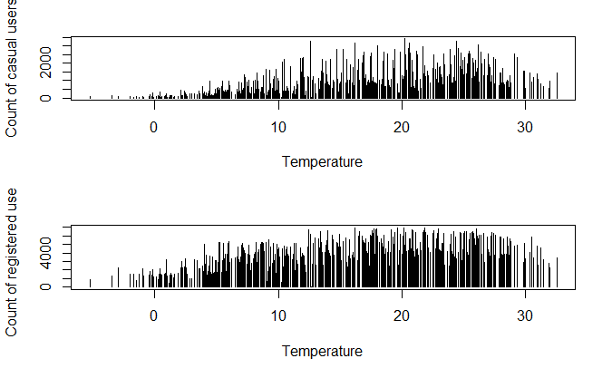

```r
day.casual <- ts(day.data$casual)
day.registered <- ts(day.data$registered)
par(mfrow=c(2,1))
plot(day.temp, day.casual, type="h", xlab="Temperature", ylab="Count of casual users")
plot(day.temp, day.registered, type="h", xlab="Temperature", ylab="Count of registered users")
```

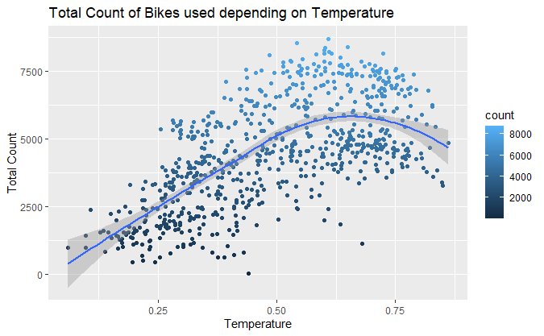

```r
# Scatterpoint for the total number of bike used

ggplot (Day, aes( x= temp, y = count, colour = count))+geom_point()+geom_smooth()+xlab("Temperature") + ylab ("Total Count")+ggtitle("Total Count of Bikes used depending on Temperature")
```

[figure not shown]

```r
#correlogram
library(corrgram)
key<- subset(Day,select = c(count,temp,atemp,humidity,windspeed,weathersit,workingday,season))
corrgram(key, order=TRUE, lower.panel=panel.shade,upper.panel=panel.pie, text.panel=panel.txt,main="Corrgram of Data")
```

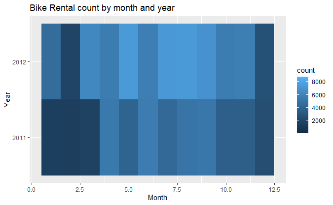

```r
#Heat map
ggplot(data=Day,aes(x=month,y=year,fill=count))+geom_tile()+labs(title="Bike Rental count by month and year",x="Month",y="Year")
```

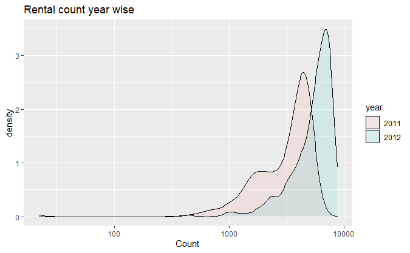

```r
#Density plot
ggplot(data=Day,aes(x=count,fill=year))+geom_density(alpha=0.1)+scale_x_log10()+labs(title="Rental count year wise",x="Count")
```

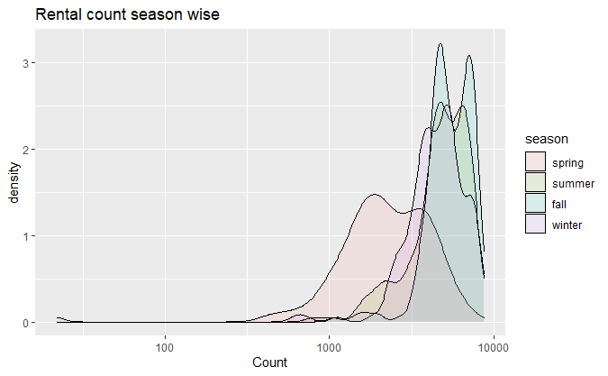

```r
ggplot(data=Day,aes(x=count,fill=season))+geom_density(alpha=0.1)+scale_x_log10()+labs(title="Rental count season wise",x="Count")
```

```r
# Plotting the association:
plot(x = 1, y = 1, xlab = "Temperature in Celcius", ylab = "Bike rentals", type = "n", main = "Association between temperature and bike rentals",
xlim = c(0, 40), ylim = c(0, 7000))


#Calculating min and max for the x-axis and y-axis:
min(day$raw.temp)
```

```
[1] 2.424346
```

```r
max(day$raw.temp)
```

```
[1] 35.32835
```

```r
min(day$casual)
```

```
[1] 2
```

```r
min(day$registered)
```

```
[1] 20
```

```r
max(day$casual)
```

```
[1] 3410
```

```r
max(day$registered)
```

```
[1] 6946
```

```r
#Adding points to the plot
day$raw.temp <- (day$temp*41)
points(day$raw.temp, day$casual, pch = 16, col = "red")
```

```r
points(day$raw.temp, day$registered, pch = 16, col = "skyblue")

# Adding a legend to the plot
legend("topleft",legend = c("casual", "registered"), col = c("red","skyblue"), pch = c(16, 16), bg = "white")
```

```r
# Calculating the correlation between raw.temp and registered users and between raw.temp and causal users
cor.reg <- cor.test(x = day$raw.temp, y = day$registered)
cor.reg
```

```
    Pearson's product-moment correlation

data:  day$raw.temp and day$registered
t = 17.323, df = 729, p-value < 2.2e-16
alternative hypothesis: true correlation is not equal to 0
95 percent confidence interval:
 0.4865508 0.5894440
sample estimates:
     cor
0.540012
```

```r
cor.cas <- cor.test(x = day$raw.temp,
y = day$casual)
cor.cas
```

```
    Pearson's product-moment correlation

data:  day$raw.temp and day$casual
t = 17.472, df = 729, p-value < 2.2e-16
alternative hypothesis: true correlation is not equal to 0
95 percent confidence interval:
 0.4900779 0.5924581
sample estimates:
      cor
0.5432847
```

```r
# Adding Correlation line and the correlation value to the plot
abline(lm(day$registered ~ day$raw.temp), lty = 6, col = "blue")

abline(lm(day$casual ~ day$raw.temp), lty = 6, col = "orange")
```

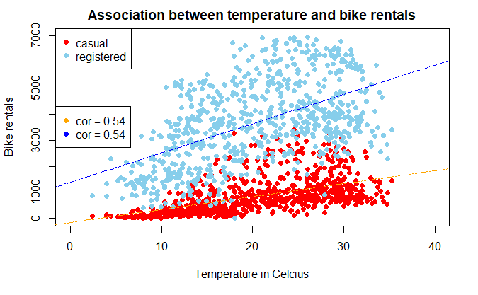

```r
reg <- paste("cor = ", round(cor(day$registered, day$raw.temp), 2), sep = "")
cas <- paste("cor = ", round(cor(day$casual, day$raw.temp), 2), sep = "")

legend("left",legend = c(cas, reg) , col = c('orange', 'blue'),pch = c(16, 16), bg = "white")
```

```r
library(lubridate)
library(tseries)
library(forecast)
library("TTR")
```

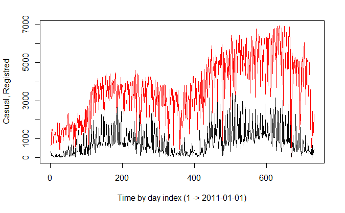

```r
seqplot.ts(day.casual, day.registered, ylab = "Casual, Registred", xlab="Time by day index (1 -> 2011-01-01)")
```

Les locations de vélos enregistrées et les locations de vélos occasionnels obtiennent leurs valeurs les plus élevées lorsque la température se situe entre 14 et 24 degrés. Et pour les deux modes de location, le nombre de locations augmente avec la température, atteignant un pic à 20 degrés, puis diminue lentement lorsque la température est élevée.

Dans ce qui suit, nous vous construisons un modèle prédictif du nombre de vélos en libre-service par jour.

Q6 - Tracez le cnt vs dteday et examinez ses modèles et irrégularités

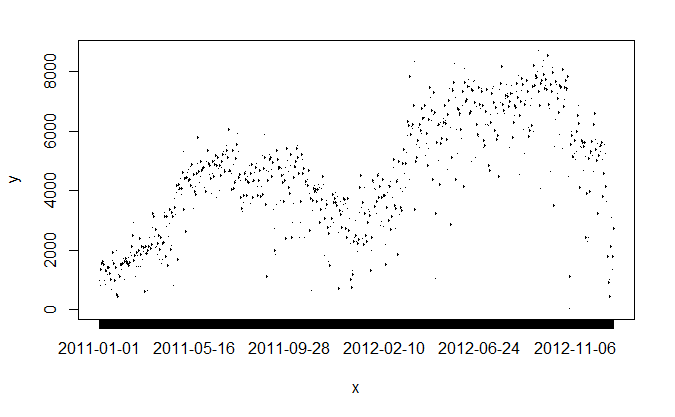

```r
Day<-data.frame(day.data)
#as.Date(day.data$dteday)
par(mfrow=c(1,1))
plot(as.factor(day.data$dteday), day.data$cnt )
```

Le nombre total de vélos de location tracé dans le temps fait un graphique en forme de double cloche, montrant la même forme générale et une augmentation de la location de vélos en 2012.

Q7 - Nettoyez les valeurs aberrantes ou manquantes si nécessaire Nous créons maintenant deux nouvelles séries chronologiques. day.cnt.raw contient la série chronologique initiale (avant le nettoyage) et day.dteday pour la dimension temporelle.

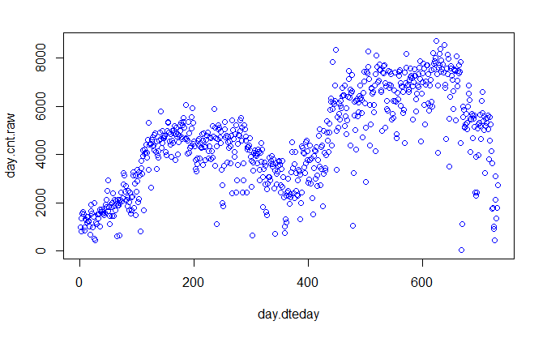

```r
day.cnt.raw <- ts(day.data$cnt)
day.dteday <- ts(as.factor(day.data$dteday))
plot(day.dteday, day.cnt.raw, col="blue")
```

Ensuite, nous supprimons les contours en utilisant tsclean (). Nous extrayons également les valeurs aberrantes.

```r
day.cnt <- tsclean(day.cnt.raw)
outliners <- day.cnt.raw[day.cnt!=day.cnt.raw]
outliners
```

```
[1] 1027 2843 3510   22 1096
```

Enfin, nous pouvons tracer la série chronologique nettoyée.

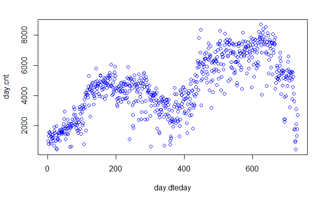

```r
plot(day.dteday, day.cnt, col="blue")
```

Q8 - Lissez votre série chronologique et comparez-la avec l’original Pour cette partie, j’utilise deux types de lissage: un lissage exponentiel simple et une moyenne mobile simple d’ordre 10.

```r
day.cnt.smoothed.se <- HoltWinters(day.cnt, beta=FALSE, gamma=FALSE)
day.cnt.smoothed.se
```

```
Holt-Winters exponential smoothing without trend and without seasonal component.

Call:
HoltWinters(x = day.cnt, beta = FALSE, gamma = FALSE)

Smoothing parameters:
 alpha: 0.2885039
 beta : FALSE
 gamma: FALSE

Coefficients:
      [,1]
a 2121.114
```

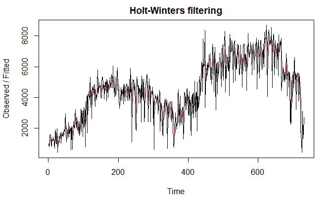

```r
plot(day.cnt.smoothed.se)
```

```r
day.cnt.smoothed.sma <- SMA(day.cnt,n=10)
day.cnt.smoothed.sma
```

```
Time Series:
Start = 1
End = 731
Frequency = 1
  [1]      NA      NA      NA      NA      NA      NA      NA      NA      NA
 [10] 1251.50 1279.30 1315.40 1321.10 1307.00 1271.80 1231.60 1180.60 1153.00
 [19] 1235.80 1296.40 1324.40 1306.30 1264.30 1263.80 1337.50 1267.70 1210.80
 [28] 1259.20 1204.00 1120.90 1116.70 1154.60 1208.60 1222.00 1194.30 1244.20
 [37] 1363.40 1417.90 1461.10 1512.00 1515.70 1554.30 1548.90 1552.80 1573.30
 [46] 1654.30 1703.50 1779.80 1919.50 1922.50 1949.90 1886.00 1883.80 1916.60
 [55] 1906.00 1870.60 1856.00 1848.70 1700.60 1722.20 1754.40 1812.20 1861.60
 [64] 1877.60 1757.40 1798.50 1814.90 1763.80 1681.50 1694.10 1693.90 1767.10
 [73] 1777.30 1775.20 1933.90 2021.10 2131.70 2254.30 2439.10 2449.10 2506.20
 [82] 2476.60 2458.50 2473.90 2504.30 2399.20 2278.10 2208.90 2115.40 2076.20
 [91] 2028.60 2041.70 2180.10 2270.60 2200.50 2312.00 2423.30 2327.90 2419.80
```

[output cut: 71 more lines]

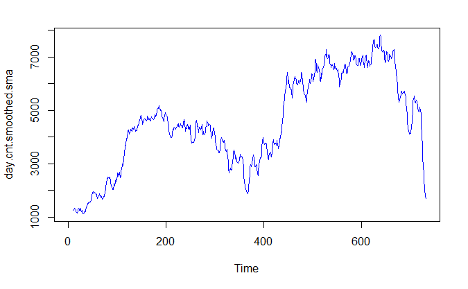

```r
plot(day.cnt.smoothed.sma, col="blue")
```

2. Décomposez vos données Nous allons maintenant utiliser la série temporelle lissée d’ordre 7, que nous nommerons ci-après cnt_ma.

Nous créons d’abord la série chronologique lissée avec l’ordre 7.

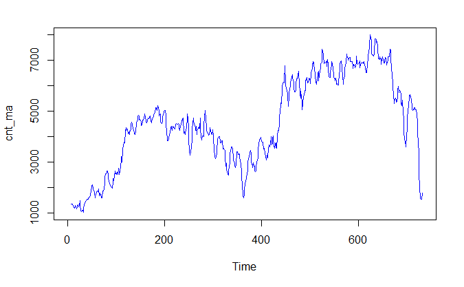

```r
cnt_ma <- SMA(day.cnt,n=7)
plot(cnt_ma, col="blue")
```

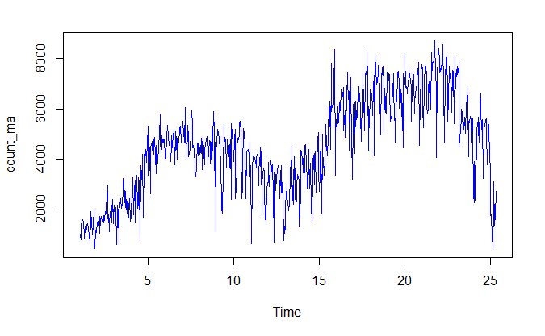

```r
count_ma <- ts(day.cnt, frequency = 30)
plot(count_ma, col="blue")
```

Q2 - La série count_ma semble-t-elle avoir des tendances ou une saisonnalité? Oui, la série temporelle count_ma montre une tendance générale à l’augmentation des loyers au cours des deux premières saisons, puis à la diminution au cours des deux dernières saisons. La série chronologique montre également un cycle répétitif à court terme au cours des deux années.

Q3 - Utilisez decompose () ou stl () pour examiner et éventuellement supprimer des composants de la série

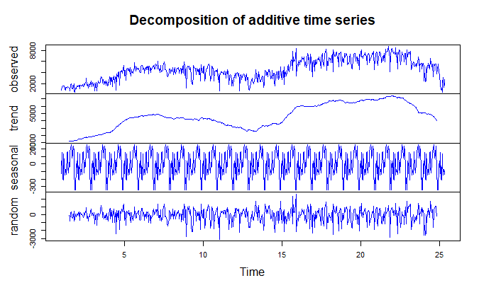

```r
count_ma.decomposed <- decompose(count_ma)
plot(count_ma.decomposed, col="blue")
```

La composante saisonnière confirme notre hypothèse et révèle un cycle mensuel saisonnier encore plus intéressant.

Q4 - Créer une série chronologique deseasonal_cnt en supprimant la composante saisonnière

```r
deseasonal_cnt <- count_ma - count_ma.decomposed$seasonal
plot(count_ma, col = "blue", xlab="Time by months")
legend(1, 8600, legend=c("count_ma", "deseasonal_cnt"), col=c("blue", "yellow"), lty=1:2, cex=0.8)
```

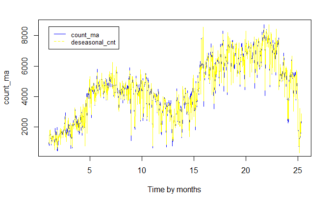

```r
lines(deseasonal_cnt, col = 'yellow')
```

3 - Stationnarité ** Q - La série count_ma est-elle stationnaire? Sinon, comment faire de la papeterie **

```r
adf.test(count_ma, alternative = "stationary")
```

```
    Augmented Dickey-Fuller Test

data:  count_ma
Dickey-Fuller = -1.3084, Lag order = 9, p-value = 0.871
alternative hypothesis: stationary
```

La valeur p est supérieure à 0,05, donc count_ma n’est pas stationnaire. ACF décrit dans quelle mesure la valeur actuelle de la série est liée à ses valeurs passées. Ici, cela confirme également que la série n’est pas stationnaire puisque l’autocorrélation diminue progressivement.

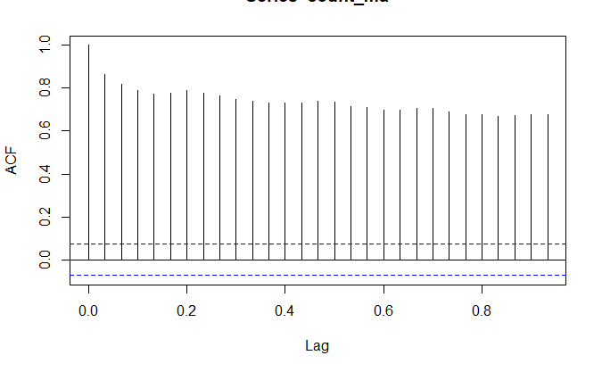

```r
acf(count_ma)
```

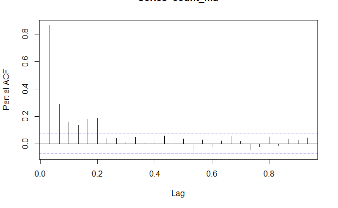

```r
pacf(count_ma)
```

Pour rendre la série chronologique stationnaire, nous utiliserons la différenciation. La différenciation consiste à soustraire chaque point de données de la série de son successeur. Premièrement, nous devons savoir combien de différences sont nécessaires.

```r
count_ma.diff1 <- diff(count_ma,differences = 1)
adf.test(count_ma.diff1, alternative = "stationary")
```

```
p-value smaller than printed p-value
```

```
    Augmented Dickey-Fuller Test

data:  count_ma.diff1
Dickey-Fuller = -13.499, Lag order = 8, p-value = 0.01
alternative hypothesis: stationary
```

La valeur p est inférieure à 0,05. count_ma.diff1 est stationnaire. Nous concluons que nous n’avons besoin que d’une différenciation pour rendre count_ma stationnaire.

```r
Day= day.data
# SIMPLE LINEAR REGRESSION
library(caTools)
set.seed(123)
split = sample.split(Day$windspeed,SplitRatio = .70)
training_set1 =subset(Day, split==TRUE)
test_set2 =subset(Day, split==FALSE)
View(training_set1)
View(test_set2)

#Fitting Simple Linear Regression to
#Traiing Set
regressor = lm(formula = windspeed ~ hum,data = training_set1)
summary(regressor)
```

```
Call:
lm(formula = windspeed ~ hum, data = training_set1)

Residuals:
     Min       1Q   Median       3Q      Max
-0.15858 -0.04976 -0.01457  0.04707  0.24436

Coefficients:
            Estimate Std. Error t value Pr(>|t|)
(Intercept)  0.27614    0.01512  18.266   <2e-16 ***
hum         -0.13910    0.02371  -5.867    8e-09 ***
---
Signif. codes:  0 ‘***’ 0.001 ‘**’ 0.01 ‘*’ 0.05 ‘.’ 0.1 ‘ ’ 1

Residual standard error: 0.07525 on 509 degrees of freedom
Multiple R-squared:  0.06334,   Adjusted R-squared:  0.0615
F-statistic: 34.42 on 1 and 509 DF,  p-value: 7.997e-09
```

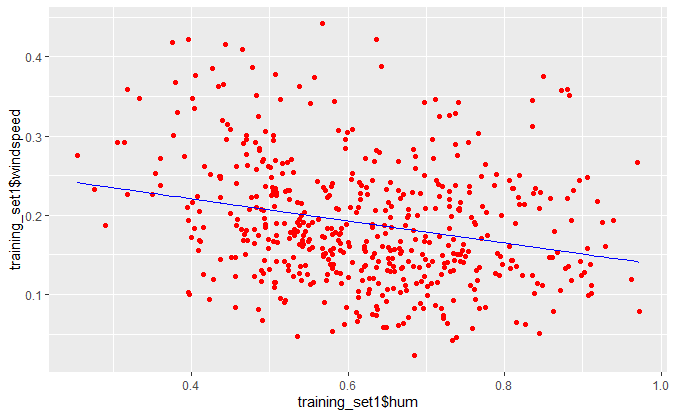

```r
#Predicting the Test Set Result
y_pred = predict(object = regressor,newdata = test_set2)
#Visualising the Training Set
library(ggplot2)
ggplot()+geom_point(aes(x=training_set1$hum,y=training_set1$windspeed),color="red")+geom_line(aes(x=training_set1$hum,y=predict(regressor,newdata=training_set1)),color="blue")
```

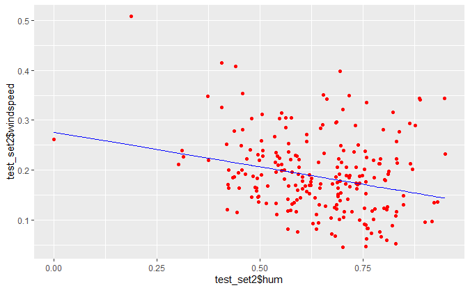

```r
#Visualizing the Test Set
ggplot()+geom_point(aes(x=test_set2$hum,y=test_set2$windspeed),color='red')+geom_line(aes(x=test_set2$hum,y=predict(regressor,newdata=test_set2)),color='blue')
```

[figure not shown]

```r
library(ggplot2)

ggplot_Temp_Rent<- ggplot(bk_sh_dy, aes(x=bk_sh_dy$actual_temp,y=bk_sh_dy$cnt))+geom_point(shape=1)+geom_smooth(method=lm)+ xlab("Actual Temp. in Celcius")+ylab("Bike Rentals")
ggplot_Temp_Rent+scale_y_continuous(breaks=c(0,1100,2345,3500,5000,6000,7000,8000))+labs(title="Total Bike Rentals Vs Actual Temperature | Intercept = 2345")
```

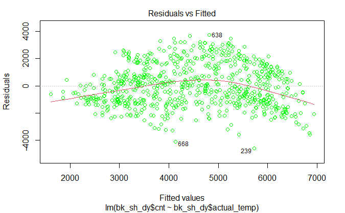

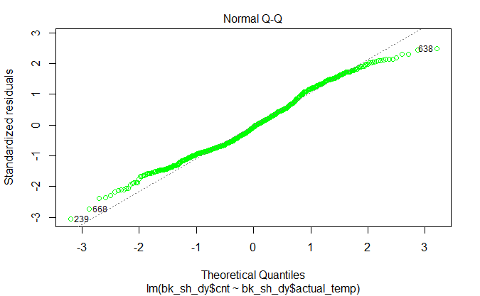

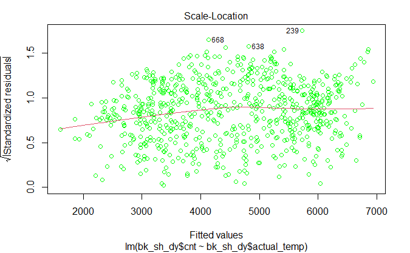

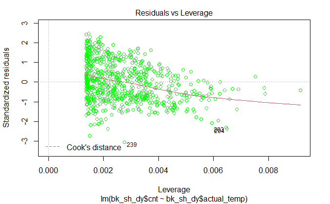

```r
lm_test<- lm(bk_sh_dy$cnt~bk_sh_dy$actual_temp)
plot(lm_test, col = "green")
```

Cependant, en vérifiant le tracé des résidus et le tracé QQ, nous pouvons voir que les résidus ont un modèle et ne sont pas normalement distribués, ce qui signifie que le modèle linéaire ne correspond pas aussi bien aux données.

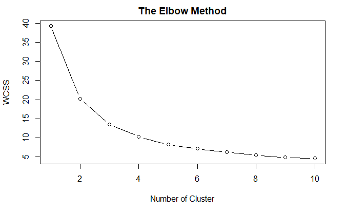

```r
#K-Means Clustering
dataset <-Day %>% select(c(temp,hum))
View(dataset)
library(cluster)
#Elbow plot
set.seed(5)
wcss = vector()
for(i in 1:10)
  wcss[i]=sum(kmeans(dataset,i)$withinss)
plot(1:10, wcss,
     type='b',
     main="The Elbow Method",
     xlab="Number of Cluster",
     ylab='WCSS')
```

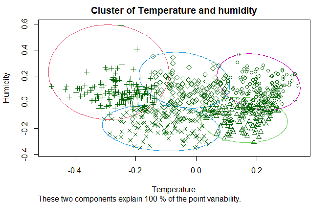

```r
#Fitting K-mean to the dataset
kmeans=kmeans(x=dataset,centers = 5 )
y_kmeans = kmeans$cluster
#Visualising the cluster
clusplot(dataset, y_kmeans,
         #labels = 2,
         #shade = T,
         lines = 0,
         color = T,
         main="Cluster of Temperature and humidity",
         xlab = 'Temperature',
         ylab = 'Humidity')
```

4 - Prévisions avec les modèles ARIMA I - Montage du modèle ARIMA Q1 - Ajuster un modèle ARIMA à deseasonal_cnt Tout d’abord, nous devons vérifier si la série chronologique a une tendance.

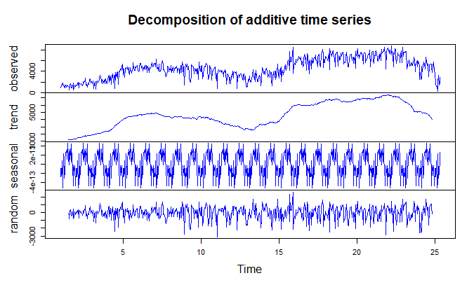

```r
deseasonal_cnt.decomposed <- decompose(deseasonal_cnt)
plot(deseasonal_cnt.decomposed, col="blue")
```

```r
adf.test(deseasonal_cnt, alternative = "stationary")
```

```
    Augmented Dickey-Fuller Test

data:  deseasonal_cnt
Dickey-Fuller = -1.2425, Lag order = 9, p-value = 0.899
alternative hypothesis: stationary
```

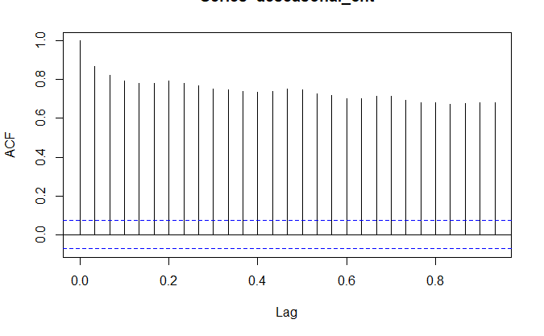

```r
acf(deseasonal_cnt)
```

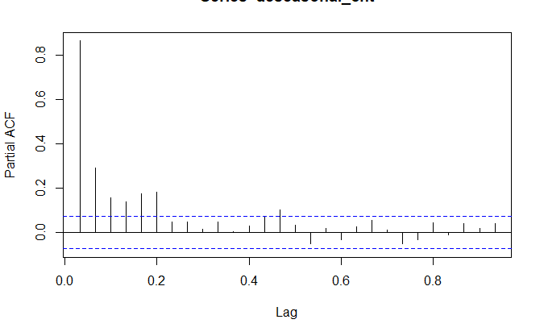

```r
pacf(deseasonal_cnt)
```

deseasonal_cnt n’est pas stationnaire, nous devons faire une différenciation.

```r
deseasonal_cnt.diff1 <- diff(deseasonal_cnt,differences = 1)
adf.test(deseasonal_cnt.diff1, alternative = "stationary")
```

```
p-value smaller than printed p-value
```

```
    Augmented Dickey-Fuller Test

data:  deseasonal_cnt.diff1
Dickey-Fuller = -13.594, Lag order = 8, p-value = 0.01
alternative hypothesis: stationary
```

deseasonal_cnt.diff1 est stationnaire, puisque sa valeur p est inférieure à 0,05 .adf.test renvoie également l’ordre de décalage q = 8, et nous avons d = 1. À partir de PACF, il est clair que dans les 6 décalages, l’AR est significatif. ce qui signifie que nous pouvons utiliser p = 6.

```r
deseasonal_cnt.arima <- arima(deseasonal_cnt.diff1, order = c(6,0,8))
```

[output not shown]

```r
deseasonal_cnt.arima
```

```
Call:
arima(x = deseasonal_cnt.diff1, order = c(6, 0, 8))

Coefficients:
          ar1     ar2      ar3      ar4      ar5      ar6      ma1      ma2
      -0.2466  0.0672  -1.0525  -0.4391  -0.0742  -0.5872  -0.3239  -0.3464
s.e.   0.2390  0.2043   0.3156   0.2940   0.1501   0.3374   0.2425   0.2659
         ma3      ma4      ma5     ma6      ma7      ma8  intercept
      0.9827  -0.2393  -0.3142  0.5325  -0.4767  -0.1443     1.4301
s.e.  0.2724   0.4544   0.1088  0.3837   0.1632   0.0520     6.1858

sigma^2 estimated as 678024:  log likelihood = -5938.24,  aic = 11908.49
```

Peut-être que le processus que nous avons suivi n’est pas la meilleure façon de sélectionner p d et q. Nous devons évaluer ce modèle et itérer.

II - Monter un ARIMA avec Auto-ARIMA Q1 - Utilisez la fonction auto.arima () pour ajuster un modèle ARIMA de deseasonal_cnt

```r
deseasonal_cnt.autoarima <- auto.arima(deseasonal_cnt, seasonal = FALSE)
deseasonal_cnt.autoarima
```

```
Series: deseasonal_cnt
ARIMA(1,1,1)

Coefficients:
         ar1      ma1
      0.3037  -0.8659
s.e.  0.0446   0.0222

sigma^2 estimated as 712654:  log likelihood=-5954.27
AIC=11914.55   AICc=11914.58   BIC=11928.33
```

Q2 - Vérifier les résidus, qui ne devraient avoir aucun modèle et être normalement distribués

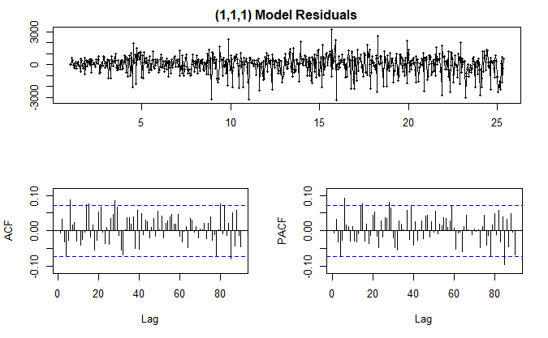

```r
deseasonal_cnt.autoarima.residuals <- deseasonal_cnt.autoarima$residuals
tsdisplay(deseasonal_cnt.autoarima.residuals, main='(1,1,1) Model Residuals')
```

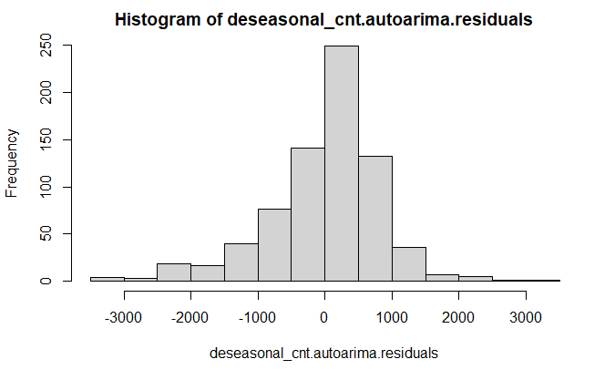

```r
hist(deseasonal_cnt.autoarima.residuals)
```

```r
shapiro.test(deseasonal_cnt.autoarima.residuals)
```

```
    Shapiro-Wilk normality test

data:  deseasonal_cnt.autoarima.residuals
W = 0.95311, p-value = 1.706e-14
```

Les résidus ne sont pas normalement distribués. La fonction auto.arima () ne nous a pas donné un bon modèle. Nous devrions itérer!

III - Évaluer et itérer Q1 - S’il y a des modèles visibles ou des biais, tracer ACF / PACF Q2 - Remontez le modèle si nécessaire. Comparez les erreurs de modèle et les critères d’ajustement tels que AIC ou BIC Nous allons former 10 modèles Arima différents en changeant la valeur de p-order.

```r
aic.values <- c()
for (p in (0:9)){
  deseasonal_cnt.arima <- arima(deseasonal_cnt, order = c(p,0,8))
  aic.values <- c(aic.values, deseasonal_cnt.arima$aic)
}
```

[output not shown]

```r
which.min(aic.values)
```

```
[1] 8
```

```r
deseasonal_cnt.arima <- arima(deseasonal_cnt, order = c(8,0,8))
deseasonal_cnt.arima
```

```
Call:
arima(x = deseasonal_cnt, order = c(8, 0, 8))

Coefficients:
         ar1     ar2      ar3     ar4      ar5      ar6     ar7      ar8     ma1
      0.2761  0.1003  -0.5356  0.4939  -0.0125  -0.0407  0.8531  -0.1541  0.1605
s.e.  0.2054  0.1272   0.0601  0.1851   0.1679   0.0651  0.1127   0.1732  0.2067
         ma2     ma3      ma4     ma5     ma6      ma7      ma8  intercept
      0.0770  0.6546  -0.1921  0.0367  0.2042  -0.7626  -0.0691   4502.200
s.e.  0.0889  0.0526   0.1875  0.1025  0.0601   0.1010   0.1447   1710.548

sigma^2 estimated as 671448:  log likelihood = -5945.3,  aic = 11926.59
```

Q3 - Calculer les prévisions à l’aide du modèle choisi

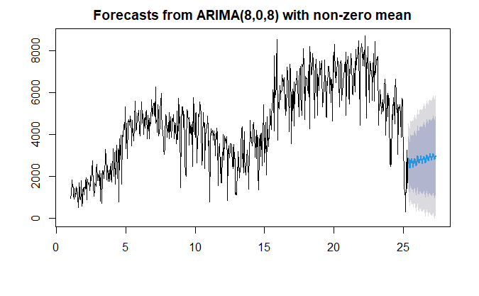

```r
deseasonal_cnt.cast <- forecast(deseasonal_cnt.arima)
plot(deseasonal_cnt.cast)
```

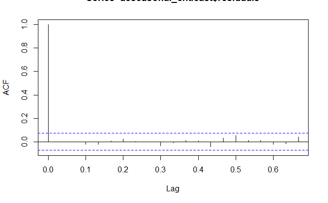

```r
acf(deseasonal_cnt.cast$residuals, lag.max=20)
```

```r
Box.test(deseasonal_cnt.cast$residuals, lag=20, type="Ljung-Box")
```

```
    Box-Ljung test

data:  deseasonal_cnt.cast$residuals
X-squared = 8.6931, df = 20, p-value = 0.9862
```

Q4 - Tracez à la fois la série chronologique originale et prévue

```r
plot(deseasonal_cnt, col="red") # original
legend(1, 8600, legend=c("Original", "Fitted"), col=c("red", "blue"), lty=1:2, cex=0.8)
```

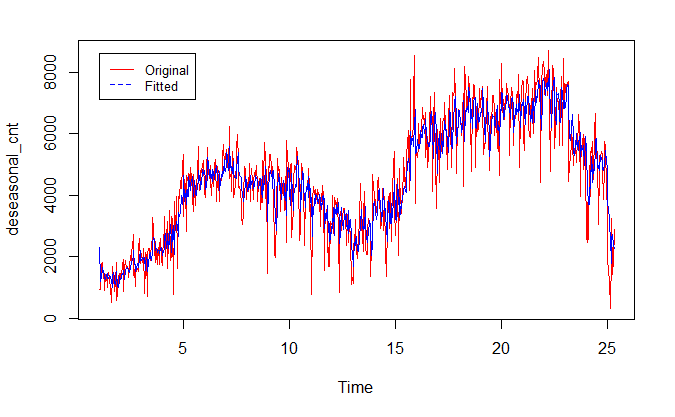

```r
lines(fitted(deseasonal_cnt.arima), col="blue") # fitted
```

IV - Prévisions Q1 - Divisez les données en séries de temps d’entraînement et de test

```r
end.time = time(deseasonal_cnt)[700]
train.set <- window(deseasonal_cnt, end=end.time)
test.set <- window(deseasonal_cnt, start=end.time)
```

Q2 - monter un modèle Arima, manuellement et avec Auto-Arima sur la partie formation

```r
manual.fit <- Arima(train.set, order=c(8, 0, 8))
manual.fc <- forecast(manual.fit, h=32)
print(paste("Accuracy of the manual Arima model : ", accuracy(manual.fc, test.set)[2,"RMSE"]))
```

```
[1] "Accuracy of the manual Arima model :  1866.30484049695"
```

```r
auto.fit <- auto.arima(train.set, seasonal = FALSE)
auto.fc <- forecast(auto.fit, h=32)
print(paste("Accuracy of the auto Arima model : ", accuracy(auto.fc, test.set)[2,"RMSE"]))
```

```
[1] "Accuracy of the auto Arima model :  1939.23863437773"
```

```r
plot(deseasonal_cnt, col="red") # original
legend(1, 8600, legend=c("Original", "Manual Arima"), col=c("red", "blue"), lty=1:2, cex=0.8)
```

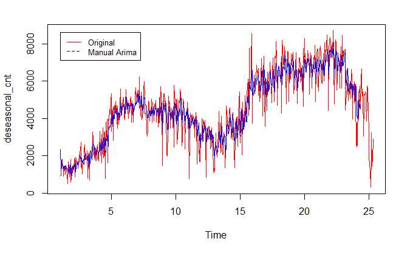

```r
lines(fitted(manual.fc), col="blue") # manuall arima
```

```r
plot(deseasonal_cnt, col="red") # original
legend(1, 8600, legend=c("Original", "Auto Arima"), col=c("red", "green"), lty=1:2, cex=0.8)
```

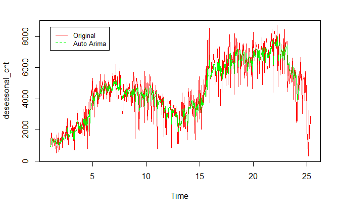

```r
lines(fitted(auto.fit), col="green") # auto arima
```

Q3 - Prévoir les 25 prochaines observations et tracer les ts originaux et les prévisions

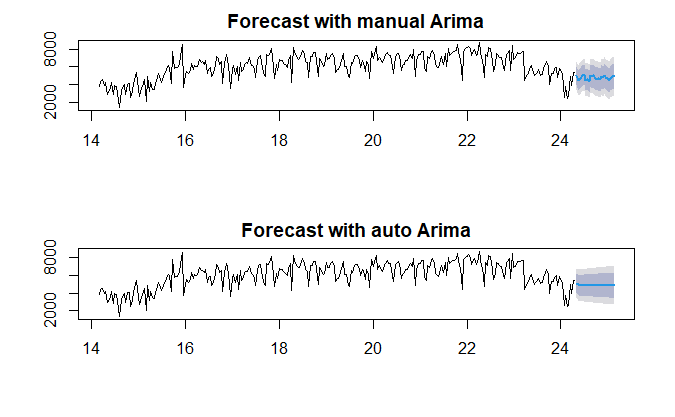

```r
deseasonal_cnt.forecast.manual <- forecast(manual.fit, h=25)
deseasonal_cnt.forecast.auto <- forecast(auto.fit, h=25)

par(mfrow=c(2,1))
plot(deseasonal_cnt.forecast.manual, main = "Forecast with manual Arima", include = test.set)
plot(deseasonal_cnt.forecast.auto, main = "Forecast with auto Arima", include = test.set)
```

Le modèle manuel Arima donne une prévision plus naturelle que celle automatique Arima.

En raison des températures douces au printemps et en hiver et du temps chaud en été et en automne, la température devrait être fortement corrélée au montant total des locations de vélos. Dans cette analyse, nous avons corrélé la température brute (température nominale convertie), la température ressentie convertie (température brute) et la moyenne des deux. Comme nous pouvons le voir dans les parcelles de la question no. 2, les trois types de températures sont en corrélation positive avec le montant total des locations de vélos. Nous voyons également que la valeur de corrélation n’est pas différente entre les trois types de températures (cor = 0,63). Quoi qu’il en soit, l’analyse montre clairement qu’il existe une relation entre ces deux variables.

Nous savons maintenant que cette température est associée au montant total des locations de vélos. C’est la raison pour laquelle nous avons testé s’il y a une différence entre la température réelle et la température ressentie. L’analyse montre qu’il existe une différence significative entre ces deux variables (t = -8,3151, df = 1450,245). Il existe toujours une différence significative entre la température réelle et la température ressentie au fil des saisons: printemps (t = -5,46, df = 350,98), été (t = -6,79, df = 364,15), automne (t = -11,37, df = 357,9) et hiver (t = -7,05, df = 351,9). Cela pourrait indiquer que la température joue un rôle important dans la location de vélos.

En raison de ces résultats, nous avons recherché l’association entre les deux groupes (enregistrés vs occasionnels) en fonction de la température. Comme nous pouvons le voir sur le graphique, au fur et à mesure que la température augmente, le nombre de locations de vélos augmente également chez les deux utilisateurs. Il semble que les utilisateurs enregistrés louent encore plus de vélos que les utilisateurs occasionnels. C’est pourquoi nous avons calculé la corrélation entre les deux utilisateurs et la température réelle. Il montre que la corrélation est égale pour les deux groupes (cor = 0,54). La différence de présentation pourrait être biaisée en raison du nombre inégal d’utilisateurs enregistrés (max = 6946) et occasionnels (max = 3410). Cependant, le graphique confirme en partie le rôle important de la température.

Ensuite, à la question 5, nous avons calculé une régression linéaire, car nous pensions que la météo et les vacances seraient de bons prédicteurs de la location de vélos. Cela montre clairement que les vacances sont un prédicteur négatif significatif (estimation = -929,5). Il montre également que le temps beau par rapport au temps nuageux (par défaut) est un prédicteur positif significatif (estimation = 848,5) et le temps humide par rapport à l’étude météorologique est un prédicteur négatif significatif (estimation = -2255,2) de la location de vélos. Le mauvais temps n’était pas inclus car à cette époque, il n’y avait pas de location de vélos.

Maintenant, nous avons utilisé un test anova, qu’il y ait des effets sur la météo et les vacances ou non. L’anova a montré un effet significatif pour le temps (valeur F = 41,010, Df = 2, valeur p <0,01) mais un effet non significatif pour les vacances (valeur F = 3797, Df = 1, valeur p = 0,05173) . Ensuite, nous avons comparé les trois types de temps différents avec le TukeyHSD. Les moyens de location de vélos en fonction du temps «beau-nuageux», «humide-nuageux» et «humide-agréable» différaient de manière significative (chaque valeur p <0,01). Cela signifie que la météo et la température affectent le nombre de locations de vélos.

En question non. 6 nous avons tracé l’humidité moyenne, la température moyenne, la vitesse moyenne du vent et les locations totales moyennes par mois. Comme nous pouvons le voir, le montant total des locations de vélos augmente avec la température par mois. Alors qu’il semble que les locations soient indépendantes de la vitesse du vent et de l’humidité, car elles sont quasi constantes au fil des mois. Cela confirme également d’une part la forte corrélation entre les locations et la température et d’autre part que le beau temps pourrait être un bon prédicteur.

À la question 7, nous avons créé une fonction personnalisée. Comme nous pouvons le voir, la fonction personnalisée nous permet de définir nos propres limites définies sur la situation météorologique pour savoir combien de jours étaient appropriés pour faire du vélo dans différentes conditions. Les résultats montrent que très peu de jours étaient inférieurs à 5 ° C, avec une vitesse du vent d’au moins 40 km / h et un temps nuageux à pluvieux. Si nous examinons les distributions dans la mission précédente, cela montre que la vitesse du vent en général n’était pas très élevée à Washington D.C. et que les températures moyennes ne sont pas tombées en dessous de 10 ° C. Avec des limites plus strictes de min. 10 ° C, vitesse du vent de 20 km / h et exclusion des conditions météorologiques humides, seule la moitié environ des jours était suitalbe pour une randonnée à vélo. Cela pourrait être important pour les recherches futures. Avec cette fonction, vous pouvez calculer le nombre de jours appropriés pour faire du vélo dans différentes villes. Avec ces résultats, les systèmes de location de vélos pourraient être mis en place dans les villes avec de nombreux jours appropriés et surtout réduire les coûts.

En conclusion, nous pouvons dire que le nombre de locations de vélos dépend principalement de la météo et de la température réelle et ressentie. L’analyse montre qu’il existe une relation positive entre le nombre de locations de vélos et la température. Et comme nous pouvons le voir dans l’intrigue de la question no. 6 le montant moyen des locations de vélos augmente et diminue avec la température. Les gens louent donc principalement des vélos les jours de beau temps et la température est agréable. Cela pourrait être important pour la planification de nouvelles stations de location de vélos.